# Carbon Bombs

Prozess: Ausbeutung zusätzlicher fossiler Brennstoffvorkommen

## Notizen Carbon Bombs

### Carbon Budget, geplante und hoffentlich gestrandete Assets.

| Größe | Wert | Quelle |
| --- | --- | --- |
| Beziehung kumulative Emissionen / Temperaturerhöhung (TCRE) | 0.44C je 1.000 GtCO2 | Tokarska & Matthews (2021) |

[output not shown]

20220520-carbon-bombs.md

> The world’s biggest fossil fuel firms are quietly planning scores of “carbon bomb” oil and gas projects that would drive the climate past internationally agreed temperature limits with catastrophic global impacts, a Guardian investigation show (Taylor & Carrington, 2022)

Recherchen des Guardian, zum großen Teil basierend auf Studien von Urgewald:

> Die Liste der Unternehmen mit den größten Förderplänen führt Quatar Energy an, gefolgt von Gazprom, Saudi Aramco, ExxonMobil und dem brasilianischen Ölgiganten Petrobras. Auf Platz neun und zehn stehen der niederländische Konzern Shell und die britische BP. (“Geplante Öl- und Gasprojekte weltweit,” 2022)

HeinzWittenbrink 20.5.2022 06:49:50 in Public

> geben die größten Öl- und Gaskonzerne für die Erschließung der Rohstoffe rund 103 Millionen US-Dollar pro Tag bis 2030 aus. (“Geplante Öl- und Gasprojekte weltweit,” 2022)

HeinzWittenbrink 20.5.2022 06:49:46 in Public

> Rund 60 Prozent der Bohrungen haben bereits begonnen, für eine Mehrheit gebe es auch schon endgültige finanzielle Zusagen. (“Geplante Öl- und Gasprojekte weltweit,” 2022)

HeinzWittenbrink 20.5.2022 06:49:30 in Public

> Längerfristig könnten diese Projekte sogar bis zu 646 Milliarden Tonnen CO₂ produzieren. Das ist mehr als das noch verfügbare weltweite CO₂-Budget , was noch bleibt, um das 1,5-Grad-Limit einzuhalten. Zum Vergleich: Derzeit geben alle Staaten der Welt rund 37 Milliarden CO₂ pro Jahr in die Atmosphäre ab. (“Geplante Öl- und Gasprojekte weltweit,” 2022)

HeinzWittenbrink 20.5.2022 06:49:05 in Public

> entspräche umgerechnet rund 97 Milliarden Tonnen CO₂-Äquivalente und damit so viel wie China nach heutigem Stand innerhalb eines Jahrzehnts ausstößt, heißt es in einer Recherche des britischen »Guardian« (“Geplante Öl- und Gasprojekte weltweit,” 2022)

HeinzWittenbrink 20.5.2022 06:48:53 in Public

> Sie planen eine massive Ausweitung ihrer Geschäfte: Allein in den nächsten sieben Jahren sollen Förderprojekte starten, die rund 192 Milliarden Barrel der klimaschädlichen Rohstoffe aus dem Boden holen sollen. (“Geplante Öl- und Gasprojekte weltweit,” 2022)

—

## ▼ 51 [Revealed: the ‘carbon bombs’ set to trigger catastrophic climate breakdown](https://www.theguardian.com/environment/ng-interactive/2022/may/11/fossil-fuel-carbon-bombs-climate-breakdown-oil-gas) www.theguardian.com

HeinzWittenbrink 12.5.2022 07:00:09 in Public

> Reflecting on the war in Ukraine, he said: “Countries could become so consumed by the immediate fossil fuel supply gap that they neglect or knee-cap policies to cut fossil fuel use. This is madness. Addiction to fossil fuels is mutually assured destruction (Taylor & Carrington, 2022)

HeinzWittenbrink 12.5.2022 06:59:31 in Public

> The Guardian’s investigation has provided an answer to the question of how great a danger the plans of oil and gas companies pose to the climate. (Taylor & Carrington, 2022)

HeinzWittenbrink 12.5.2022 06:59:03 in Public

> Petrobras is following its strategy of maximising the value of its portfolio, [with 99% of the investment on exploration] focusing on deepwater and ultra-deepwater assets.” (Taylor & Carrington, 2022)

HeinzWittenbrink 12.5.2022 06:58:27 in Public

> document states that profits from oil and gas projects are significantly higher than from investments in renewable energy. (Taylor & Carrington, 2022)

HeinzWittenbrink 12.5.2022 06:57:12 in Public

> The US is also high on the list of the biggest per capita subsidies for all fossil fuels with $2,000 a year, behind only Saudi Arabia ($4,550) and Russia ($3,560). After these countries, only Iran ($1815) is ahead of Australia ($1730) and Canada ($1690). (Taylor & Carrington, 2022)

HeinzWittenbrink 12.5.2022 06:56:50 in Public

HeinzWittenbrink 12.5.2022 06:56:30 in Public

> drivers in the US, Canada and Australia, along with Saudi Arabia, are the world’s biggest beneficiaries of subsidies for road fuels, with some governments under pressure to increase these during the current energy crisis. (Taylor & Carrington, 2022)

HeinzWittenbrink 12.5.2022 06:56:20 in Public

> When the damage from the climate crisis and air pollution is accounted for, the fossil fuel subsidies reach $6tn a year, according to the International Monetary Fund (IMF). Guardian analysis shows this is equivalent to $11m a minute globally, $4m a minute in China and more than $1m in the US. (Taylor & Carrington, 2022)

HeinzWittenbrink 12.5.2022 06:55:58 in Public

> huge ongoing subsidies for the fuels, making them far cheaper than their true cost when the damage they cause is included – especially air pollution, which kills 7 million people a year (Taylor & Carrington, 2022)

HeinzWittenbrink 12.5.2022 06:55:45 in Public

> separate recent analysis based on Rystad Energy data from April, after Russia’s invasion of Ukraine, found that 20 of the world’s biggest oil and gas companies remained on course to spend huge sums – $932bn – by the end of 2030 developing new oil and gas fields (Taylor & Carrington, 2022)

HeinzWittenbrink 12.5.2022 06:55:32 in Public

> “Companies that continue to develop projects based on business-as-usual demand are betting on the failure of policy action on climate and underestimating the disruptive potential of new technologies, such as renewables and battery storage,” said Mike Coffin at Carbon Tracker (Taylor & Carrington, 2022)

HeinzWittenbrink 12.5.2022 06:55:03 in Public

> governments act on the scientific advice to rapidly reduce carbon emissions by boosting clean energy and cutting fossil fuel burning, the companies would have to write off these colossal sums as losses, hitting shareholders, pension funds and public finances. (Taylor & Carrington, 2022)

HeinzWittenbrink 12.5.2022 06:54:30 in Public

> The Carbon Tracker data, compiled in September, uses a temperature of 1.65C to represent the well below 2C target and finds that 27% of the companies’ projected investments are incompatible with this. (Taylor & Carrington, 2022)

HeinzWittenbrink 12.5.2022 06:54:06 in Public

> companies have developed further project options that might lead them to spend an additional $84m a day that would not even be compatible with a devastating 2.7C of global heating. (Taylor & Carrington, 2022)

HeinzWittenbrink 12.5.2022 06:53:40 in Public

HeinzWittenbrink 12.5.2022 06:53:18 in Public

> “We’ve given you a lovely little chart,” said Murray Auchincloss, BP’s chief financial officer. “Certainly, it’s possible that we’re getting more cash than we know what to do with. For now, I’m going to be conservative and manage the company as if it’s $40 [a barrel] oil. Anything we could get above that just helps, obviously.” At the time, the oil price exceeded $90; today it is $106. (Taylor & Carrington, 2022)

HeinzWittenbrink 12.5.2022 06:52:14 in Public

> Prof Kevin Anderson, from the Tyndall Centre of Climate Research, University of Manchester and Uppsala University, Sweden, said the scale of planned production in the face of all the evidence suggested big oil and its political supporters either did not believe the climate science or thought their extreme wealth could somehow protect them and their children from the devastating consequences. (Taylor & Carrington, 2022)

HeinzWittenbrink 12.5.2022 06:51:15 in Public

HeinzWittenbrink 12.5.2022 06:51:07 in Public

> The study is based on data from Rystad Energy but, rather than focusing on total barrels, it identifies the mega projects potentially responsible for the biggest emissions (Taylor & Carrington, 2022)

HeinzWittenbrink 12.5.2022 06:50:37 in Public

> Kühne, the director of the Leave it in the Ground Initiative, said in the first instance, the 40% of projects that had not yet started production must be stopped if the world was to avoid sliding ever more quickly towards catastrophe, (Taylor & Carrington, 2022)

HeinzWittenbrink 12.5.2022 06:50:07 in Public

> brutal calculation that the interest of fossil fuel giants and their billions in profit is more important than the lives of people who are overwhelmingly black, brown and poor (Taylor & Carrington, 2022)

HeinzWittenbrink 12.5.2022 06:49:50 in Public

> Asad Rehman, a leading climate justice activist in the UK who was at the forefront of a global network of indigenous activists and civil society campaigners in Glasgow, accused the US, Canada and Australia of “rank hypocrisy (Taylor & Carrington, 2022)

HeinzWittenbrink 12.5.2022 06:49:40 in Public

> months after many of the world’s politicians positioned themselves as climate leaders during the Cop26 conference in Glasgow, they were giving the green light to a massive global expansion of oil and gas production that scientists warn would push civilisation to the brink (Taylor & Carrington, 2022)

HeinzWittenbrink 12.5.2022 06:49:29 in Public

HeinzWittenbrink 12.5.2022 06:49:10 in Public

> specific definition: projects capable of pumping at least 1bn tonnes of CO2 emissions over their lifetimes. (Taylor & Carrington, 2022)

HeinzWittenbrink 12.5.2022 06:49:01 in Public

> carbon bomb has been widely used in climate circles for the past decade to describe large fossil fuel projects or other big sources of carbon. (Taylor & Carrington, 2022)

HeinzWittenbrink 12.5.2022 06:48:48 in Public

> Research shared exclusively with the Guardian has identified the Cabo Delgado development as one of 195 carbon bombs, which – unless stopped – will drive catastrophic climate breakdown around the world. (Taylor & Carrington, 2022)

HeinzWittenbrink 12.5.2022 06:48:39 in Public

HeinzWittenbrink 12.5.2022 06:48:17 in Public

HeinzWittenbrink 12.5.2022 06:47:53 in Public

> A separate analysis for the Guardian by Urgewald on the average annual investment in oil and gas exploration over the past three years shows that, along with Shell, three large but rarely scrutinised Chinese companies occupy the top four slots: (Taylor & Carrington, 2022)

HeinzWittenbrink 12.5.2022 06:47:34 in Public

> Two-thirds of the 116bn barrels of oil and gas projects companies are financially committed to are in the Middle East, Russia and North America, according to data provided by Rystad Energy. (Taylor & Carrington, 2022)

HeinzWittenbrink 12.5.2022 06:46:49 in Public

> State oil companies lead the Urgewald short-term expansion list, with Qatar Energy, Russia’s Gazprom and Saudi Aramco the top three (Taylor & Carrington, 2022)

HeinzWittenbrink 12.5.2022 06:45:30 in Public

> provided by analysts at Urgewald, who used data from Rystad Energy, the industry standard source but not publicly available (Taylor & Carrington, 2022)

HeinzWittenbrink 12.5.2022 06:45:21 in Public

> The Guardian’s investigation has found that in the next seven or so years, they are likely to start producing oil and gas from projects that would ultimately deliver 192bn barrels, the equivalent of a decade of today’s emissions from China. (Taylor & Carrington, 2022)

HeinzWittenbrink 12.5.2022 06:45:04 in Public

> the projects go ahead, they will blow the world’s rapidly shrinking cap on emissions that must be kept to enable a liveable future – known as the carbon budget. (Taylor & Carrington, 2022)

HeinzWittenbrink 12.5.2022 06:44:22 in Public

> And who benefits most from the fossil fuel subsidies that hide the true damage they cause? (Taylor & Carrington, 2022)

HeinzWittenbrink 12.5.2022 06:44:11 in Public

> followed the money: how much is going to be spent on oil and gas (Taylor & Carrington, 2022)

HeinzWittenbrink 12.5.2022 06:43:57 in Public

> where exactly are the biggest projects (Taylor & Carrington, 2022)

HeinzWittenbrink 12.5.2022 06:43:53 in Public

> how much production is due (Taylor & Carrington, 2022)

HeinzWittenbrink 12.5.2022 06:43:37 in Public

> But a global team of Guardian environment reporters has worked with leading thinktanks, analysts and academics across the world over the past five months and now we can answer a series of questions that reveal the scale of the sector’s plans. (Taylor & Carrington, 2022)

HeinzWittenbrink 12.5.2022 06:43:21 in Public

> The failure of countries to “build back greener” after the Covid-19 pandemic or the 2008 financial crash was not a good omen, and Guterres said: “Fossil fuel interests are now cynically using the war in Ukraine to lock in a high-carbon future.” (Taylor & Carrington, 2022)

HeinzWittenbrink 12.5.2022 06:42:53 in Public

> In April, shocked by the latest IPCC report that said it was “now or never” to start slashing emissions, Guterres launched an outspoken attack on companies and governments whose climate actions did not match their words. (Taylor & Carrington, 2022)

HeinzWittenbrink 12.5.2022 06:42:22 in Public

> May 2021, a report from the International Energy Agency, previously seen as a conservative body, concluded there could be no new oil or gas fields or coalmines if the world was to reach net zero by 2050. (Taylor & Carrington, 2022)

HeinzWittenbrink 12.5.2022 06:42:09 in Public

> In 2015, a high-profile analysis found that to limit global temperature below 2C, half of known oil reserves and a third of gas had to stay in the ground, along with 80% of coal. (Taylor & Carrington, 2022)

HeinzWittenbrink 12.5.2022 06:41:37 in Public

> Furthermore, many of the rich countries, such as the US, that dominate international climate diplomacy and positioned themselves as climate leaders at the conference, are big players in new oil and gas projects. But unlike India, they avoided criticism (Taylor & Carrington, 2022)

HeinzWittenbrink 12.5.2022 06:40:36 in Public

> The Middle East and Russia often attract the most attention in relation to future oil and gas production but the US, Canada and Australia are among the countries with the biggest expansion plans (Taylor & Carrington, 2022)

HeinzWittenbrink 12.5.2022 06:40:16 in Public

> 195 carbon bombs, gigantic oil and gas projects that would each result in at least a billion tonnes of CO2 emissions over their lifetimes, (Taylor & Carrington, 2022)

HeinzWittenbrink 12.5.2022 06:40:03 in Public

> start of oil and gas projects that will produce greenhouse gases equivalent to a decade of CO2 emissions from China, the world’s biggest polluter (Taylor & Carrington, 2022)

HeinzWittenbrink 12.5.2022 06:39:55 in Public

> Details of the projects being planned are not easily accessible but an investigation published in the Guardian shows: (Taylor & Carrington, 2022)

HeinzWittenbrink 12.5.2022 06:39:28 in Public

> recent price rises led BP’s boss to describe the company as a “cash machine”. (Taylor & Carrington, 2022)

HeinzWittenbrink 12.5.2022 06:38:53 in Public

> The world’s biggest fossil fuel firms are quietly planning scores of “carbon bomb” oil and gas projects that would drive the climate past internationally agreed temperature limits with catastrophic global impacts, a Guardian investigation show (Taylor & Carrington, 2022)

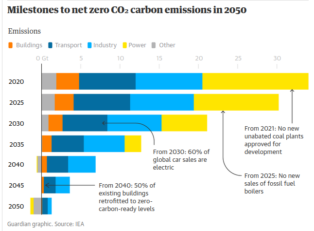

Grafik aus (Harvey, 2021)

Geplante Öl- und Gasprojekte weltweit: 195 »Kohlenstoffbomben« bedrohen das Weltklima. (2022, May 12). *Der Spiegel*. https://www.spiegel.de/wissenschaft/geplante-oel-und-gasprojekte-weltweit-195-kohlenstoffbomben-bedrohen-das-weltklima-a-75e1cce0-e16b-4e29-9d27-276f285b2413

Harvey, F. (2021, May 18). No new oil, gas or coal development if world is to reach net zero by 2050, says world energy body. *The Guardian*. https://www.theguardian.com/environment/2021/may/18/no-new-investment-in-fossil-fuels-demands-top-energy-economist

IPCC (Ed.). (2022). Summary for Policymakers. In *Climate Change 2022 – Mitigation of Climate Change. Working Group III Contribution to the IPCC Sixth Assessment Report (AR6)*. https://report.ipcc.ch/ar6wg3/pdf/IPCC_AR6_WGIII_SummaryForPolicymakers.pdf

*Policies & action EU (Update: 2021-09-15)*. (2021, September 15). Carbon Action Tracker. https://climateactiontracker.org/countries/eu/policies-action/

Taylor, M., & Carrington, D. (2022, May 11). Revealed: the “carbon bombs” set to trigger catastrophic climate breakdown. *The Guardian*. https://www.theguardian.com/environment/ng-interactive/2022/may/11/fossil-fuel-carbon-bombs-climate-breakdown-oil-gas

Tokarska, K., & Matthews, D. (2021, January 19). *Refining the remaining 1.5C “carbon budget”*. Carbon Brief. https://www.carbonbrief.org/guest-post-refining-the-remaining-1-5c-carbon-budget/